# `forcats`: working with categorical data

Author

Casey Schine adapted from Emily Malcolm-White

The R package `forcats` is designed to make working with categorical variables easier and more efficient. It provides a set of functions that allow you to manipulate and analyze categorical data with ease. In this lesson, we’ll cover the basics of the `forcats` package and some of its most useful functions.

## Categorical Variables and Factors

Categorical variables contain values that represent groups or categories. Some categories have no inherent order (nominal), while others have a meaningful order (ordinal).

Examples of categorical data include:

- Colors (red, blue, green, etc.)
- Types of vehicles (sedan, SUV, truck)
- Educational degrees (high school, college, graduate school)

In R, a **factor** is a way of storing categorical data that keeps track of both the categories and their order. These categories are called levels.

## `mpg` Data

We will play with different functions in the `forcats` packages using the `mpg` dataset from earlier in the semester.

```r
library(forcats)
library(tidyverse)
data("mpg")
library(ggthemes)
```

Let’s take a look at a side-by-side boxplot:

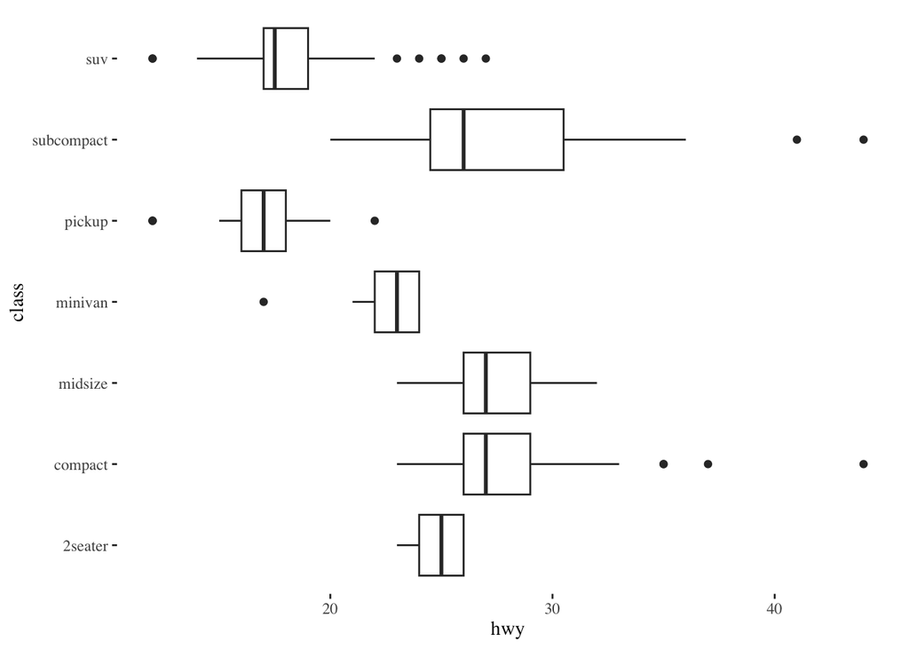

```r
# boxplot of hwy in each class

mpg |>
  ggplot(aes(y=class, x=hwy)) +
  geom_boxplot() +
  theme_tufte()
```

## Reordering Factor Levels

One of the most useful functions is `fct_relevel()`, which allows you to reorder the levels of a factor. This can be useful when you want to change the default ordering of the levels.

Is `class` a factor?

```r
# look at the mpg data and the column classes
# use is.factor() to inquire if class is a factor variable
# returns TRUE or FALSE
# with pull()

mpg |>
  pull(class) |>
  is.factor()
```

```
[1] FALSE
```

Let’s make it a factor!

```r
# use mutate to write over class with new factor variable called class
# use as.factor()

mpg <- mpg |>
  mutate(class = as.factor(class))
```

Let’s check the levels and their current ordering!

```r
# use levels() to get factor levels
# levels() requires vector so must use pull() rather than select()

mpg |>
  pull(class) |>
  is.factor()
```

```
[1] TRUE
```

```r
mpg |>
  pull(class) |>
  levels()
```

```
[1] "2seater"    "compact"    "midsize"    "minivan"    "pickup"
[6] "subcompact" "suv"
```

### Reorder the levels with `fct_relevel()`

```r
# what do we think would be a better order
# reorder using fct_relevel()
# use mutate to overwrite the existing class column

mpg <- mpg |>
  mutate(class = fct_relevel(class, c("compact","2seater",
                                      "subcompact", "midsize",
                                    "suv","minivan","pickup")))

# check the levels
mpg |>
  pull(class) |>
  levels()
```

```
[1] "compact"    "2seater"    "subcompact" "midsize"    "suv"
[6] "minivan"    "pickup"
```

Let’s recreate our side-by-side boxplot now:

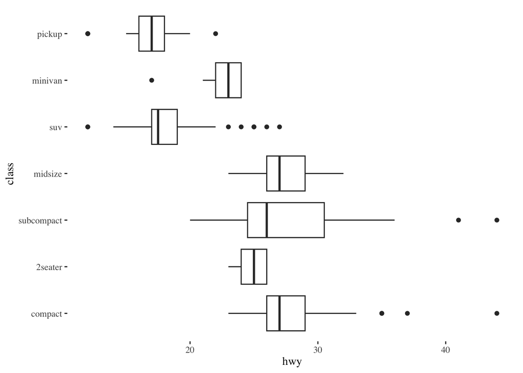

```r
# boxplot of hwy in each class
mpg |>
  ggplot(aes(x=hwy, y=class)) +
  geom_boxplot() +
  theme_tufte()
```

### Reorder levels with `fct_reorder()`

Rather than reordering them manually by typing the order, you could also re-level by some numeric criteria using `fct_reorder()`. For example:

```r
#?fct_reorder

# reorder class using median hwy mpg
# as fct_reorder(class, hwy, median)
# fct_reorder(factor, values, function)

mpg <- mpg |>
  mutate(class=fct_reorder(class, hwy, median))

# take a look at the order again
mpg |>
  pull(class) |>
  levels()
```

```
[1] "pickup"     "suv"        "minivan"    "2seater"    "subcompact"
[6] "compact"    "midsize"
```

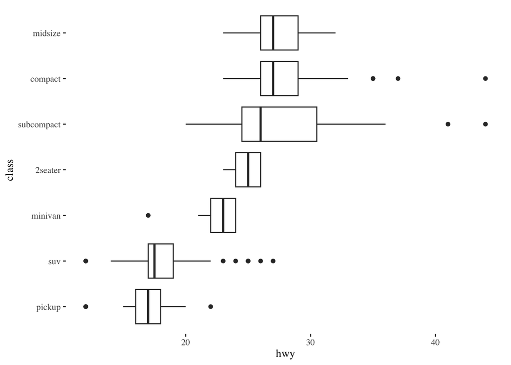

```r
# remake the boxplot again with the new order

mpg |>
  ggplot(aes(x=hwy, y=class)) +
  geom_boxplot() +
  theme_tufte()
```

Other functions you can use to reorder data include `max`, `min`, and `mean`.

## Renaming Factor levels with `fct_recode`

Sometimes you might not like the way the levels are named.

```r
# use fct_recode to change the name of a factor level in class
# fct_recode("two-seater" = "2seater")
## NEW NAME = OLD NAME

mpg <- mpg |>
  mutate(class=fct_recode(class, "two-seater"="2seater"))


# take another look at the factor

mpg |>
  pull(class) |>
  levels()
```

```
[1] "pickup"     "suv"        "minivan"    "two-seater" "subcompact"
[6] "compact"    "midsize"
```

## Factor Collapsing with `fct_collapse()`

Let’s say we wanted to create only two categories – cars and larger vehicles.

```r
# use fct_collapse to collapse class into cars and big factors
# mutate on new variable called class_two
# fct_collapse(class, cars = c("compact", "subcompact", "midsize", "two-seater"), big = c("pickup", "suv", "minivan"))

mpg <- mpg |>
  mutate(class_two = fct_collapse(class,
                                  cars = c("compact",
                                           "subcompact",
                                           "midsize",
                                           "two-seater"),
                                  big = c("pickup", "suv",
                                          "minivan")))


# take a look at the new variable factor levels
mpg |>
  pull(class_two) |>
  levels()
```

```
[1] "big"  "cars"
```

## Lumping into an other category

- `fct_lump_min()`: lumps levels that appear fewer than min times.
- `fct_lump_prop()`: lumps levels that appear in fewer than (or equal to) prop * n times.
- `fct_lump_n()` lumps all levels except for the n most frequent (or least frequent if n < 0)

Now let’s look at the data for manufacturers:

```r
# count manufacturers in dataset

mpg |>
  count(manufacturer)
```

```
# A tibble: 15 × 2
   manufacturer     n
   <chr>        <int>
 1 audi            18
 2 chevrolet       19
 3 dodge           37
 4 ford            25
 5 honda            9
 6 hyundai         14
 7 jeep             8
 8 land rover       4
 9 lincoln          3
10 mercury          4
11 nissan          13
12 pontiac          5
13 subaru          14
14 toyota          34
15 volkswagen      27
```

Let’s say we wanted only the manufacturers with at least 15 cars produced. Everything else we want to just be other:

```r
# ?fct_lump_min

# make manufacturer lump variable using fct_lump_min(15)
# lumps anything that does not have a minimum number of entries
# use mutate() to make variable a new column

mpg <- mpg |>
  mutate(man_lump = fct_lump_min(manufacturer, 15))



# look at the result with count()

mpg |>
  count(man_lump)
```

```
# A tibble: 7 × 2
  man_lump       n
  <fct>      <int>
1 audi          18
2 chevrolet     19
3 dodge         37
4 ford          25
5 toyota        34
6 volkswagen    27
7 Other         74
```

```r
# now with fct_lump_n() for the top 5
# lumps everything that isn't the 5 highest manufacturers
# as a new column

mpg <- mpg |>
  mutate(man_lump_n = fct_lump_n(manufacturer, 5))

# look at the result with count()

mpg |>
  count(man_lump_n)
```

```
# A tibble: 6 × 2
  man_lump_n     n
  <fct>      <int>
1 chevrolet     19
2 dodge         37
3 ford          25
4 toyota        34
5 volkswagen    27
6 Other         92
```

## Kable Tables

Create a table using kableExtra:

```r
library(kableExtra)

# make table for manufacturer before and after lumping
# using kbl() |> kable_styling()

mpg |>
  count(manufacturer) |>
  kbl() |>
  kable_styling()
```

| manufacturer | n |
| --- | --- |
| audi | 18 |
| chevrolet | 19 |
| dodge | 37 |
| ford | 25 |
| honda | 9 |
| hyundai | 14 |
| jeep | 8 |
| land rover | 4 |
| lincoln | 3 |
| mercury | 4 |
| nissan | 13 |
| pontiac | 5 |
| subaru | 14 |
| toyota | 34 |
| volkswagen | 27 |

```r
# using lumped manufacturers

mpg |>
  count(man_lump_n) |>
  kbl() |>
  kable_styling()
```

| man_lump_n | n |
| --- | --- |
| chevrolet | 19 |
| dodge | 37 |
| ford | 25 |
| toyota | 34 |
| volkswagen | 27 |
| Other | 92 |

If we want to change the order of items that appear in our table we can use some of the tricks that we just learned for reordering factors!

We can also use Kable tables to display summary data.

```r
# we can use group_by() and summarize() to get statistics for each group
# calculate median hwy miles per gallon

mpg |>
  group_by(class) |>
  summarize(median_hwy = median(hwy)) |>
  kbl() |>
  kable_styling()
```

| class | median_hwy |
| --- | --- |
| pickup | 17.0 |
| suv | 17.5 |
| minivan | 23.0 |
| two-seater | 25.0 |
| subcompact | 26.0 |
| compact | 27.0 |
| midsize | 27.0 |

```r
# we can also use the fct_reorder() function to reorder the factor by a calculated value (as we did above)
# class = fct_reorder(class, hwy, .fun = median)
# calculate median hwy and add count using the n() function in summarize

mpg |>
  group_by(class) |>
  summarize(median_hwy = median(hwy),
            count=n()) |>
  kbl() |>
  kable_styling()
```

| class | median_hwy | count |
| --- | --- | --- |
| pickup | 17.0 | 33 |
| suv | 17.5 | 62 |
| minivan | 23.0 | 11 |
| two-seater | 25.0 | 5 |
| subcompact | 26.0 | 35 |
| compact | 27.0 | 47 |
| midsize | 27.0 | 41 |

```r
# add caption for the table using the caption argument in kbl()
```

We can also control aspects of the table and how it looks using arguments in the `kbl()` and `kable_styling()` functions.

```r
# how can we control aspects of the table
#?kbl to look at some of the options

# can set the number of digits using the digits=x argument in kbl()
# add caption for the table using the caption argument in kbl()
# also col.names=c() argument to change the column names for the output table

mpg |>
  group_by(class) |>
  summarize(median_hwy = median(hwy),
            count=n()) |>
  kbl(digits=0,
      col.names=c("Class", "Median mpg", "Count"),
      caption="Table showing the median highway miles per gallon for different classes of cars") |>
  kable_styling()
```

Table showing the median highway miles per gallon for different classes of cars

| Class | Median mpg | Count |
| --- | --- | --- |
| pickup | 17 | 33 |
| suv | 18 | 62 |
| minivan | 23 | 11 |
| two-seater | 25 | 5 |
| subcompact | 26 | 35 |
| compact | 27 | 47 |
| midsize | 27 | 41 |

**Difference between `kbl()` and `kable_styling()`**

`kbl()` Turns R data frame or tibble into a basic table structure. It can handle basic attributes like the number of digits shown in the table or adding a caption or changing column names.

`kable_styling()` Takes the output from `kbl()` and applies themes and layouts. Controls the visual presentation, including table width and alignment within the rendered document

If we take the table we just made and apply some of the `kable_styling()` options we can see the changes:

```r
mpg |>
  group_by(class) |>
  summarize(median_hwy = median(hwy),
            count=n()) |>
  kbl(digits=0,
      col.names=c("Class", "Median mpg", "Count"),
      caption="Median highway miles per gallon for different classes of cars") |>
  kable_classic( # applies a different table theme
                "hover", # highlights rows when you put your mouse over them
                full_width=FALSE, # table won't take up full width
                html_font = "Cambria",
                position="center"
                )
```

Median highway miles per gallon for different classes of cars

| Class | Median mpg | Count |
| --- | --- | --- |
| pickup | 17 | 33 |
| suv | 18 | 62 |
| minivan | 23 | 11 |
| two-seater | 25 | 5 |
| subcompact | 26 | 35 |
| compact | 27 | 47 |
| midsize | 27 | 41 |

This [website](https://haozhu233.github.io/kableExtra/awesome_table_in_html.html) gives excellent examples for all of the options you have for `kable_styling()` with html tables. You can get very fancy with some of the options.

## Heatmaps

A heatmap is a great way to summarize information across categories. Heatmaps use **color** to represent a numeric value for each combination of two categorical variables.

Let’s start by looking at two categorical variables: vehicle `class` and drive type (`drv`).

```r
# count the number of observations in each combination
# of class and drive type

mpg |>
  count(class, drv)
```

```
# A tibble: 12 × 3
   class      drv       n
   <fct>      <chr> <int>
 1 pickup     4        33
 2 suv        4        51
 3 suv        r        11
 4 minivan    f        11
 5 two-seater r         5
 6 subcompact 4         4
 7 subcompact f        22
 8 subcompact r         9
 9 compact    4        12
10 compact    f        35
11 midsize    4         3
12 midsize    f        38
```

We can display these counts as a heatmap using `geom_tile()`:

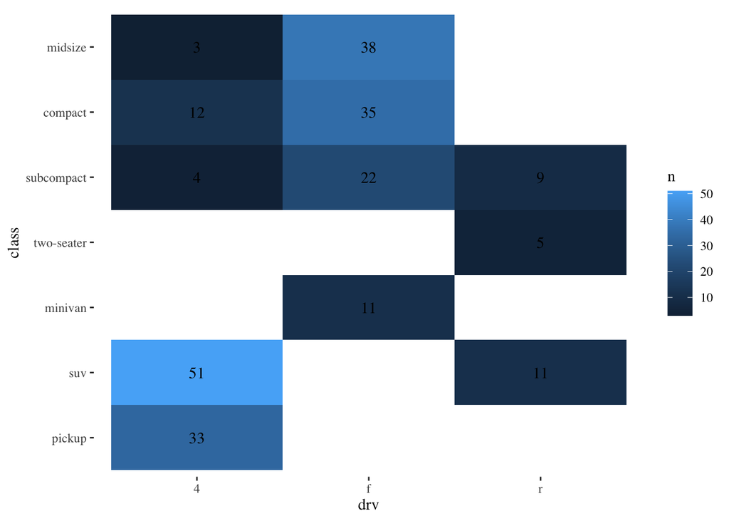

```r
# count(class, drv) and set x to drv, y to class, and fill to n

mpg |>
  count(class, drv) |>
  ggplot(aes(x=drv, y=class, fill=n)) +
  geom_tile() +
  geom_text(aes(label=n)) +
  theme_tufte()
```

Each tile represents one combination of vehicle class and drive type. The color of the tile represents the number of observations in that combination.

### Heatmaps of summary values

The color does not have to represent a count. We can calculate a summary statistic for each combination of categories and use that value instead.

```r
# calculate mean highway MPG for each combination
# of class and drive type

mpg |>
  group_by(class, drv) |>
  summarize(mean_hwy=mean(hwy))
```

```
# A tibble: 12 × 3
# Groups:   class [7]
   class      drv   mean_hwy
   <fct>      <chr>    <dbl>
 1 pickup     4         16.9
 2 suv        4         18.3
 3 suv        r         17.5
 4 minivan    f         22.4
 5 two-seater r         24.8
 6 subcompact 4         26
 7 subcompact f         30.5
 8 subcompact r         23.2
 9 compact    4         25.8
10 compact    f         29.1
11 midsize    4         24
12 midsize    f         27.6
```

Now we can map `mean_hwy` to `fill` instead:

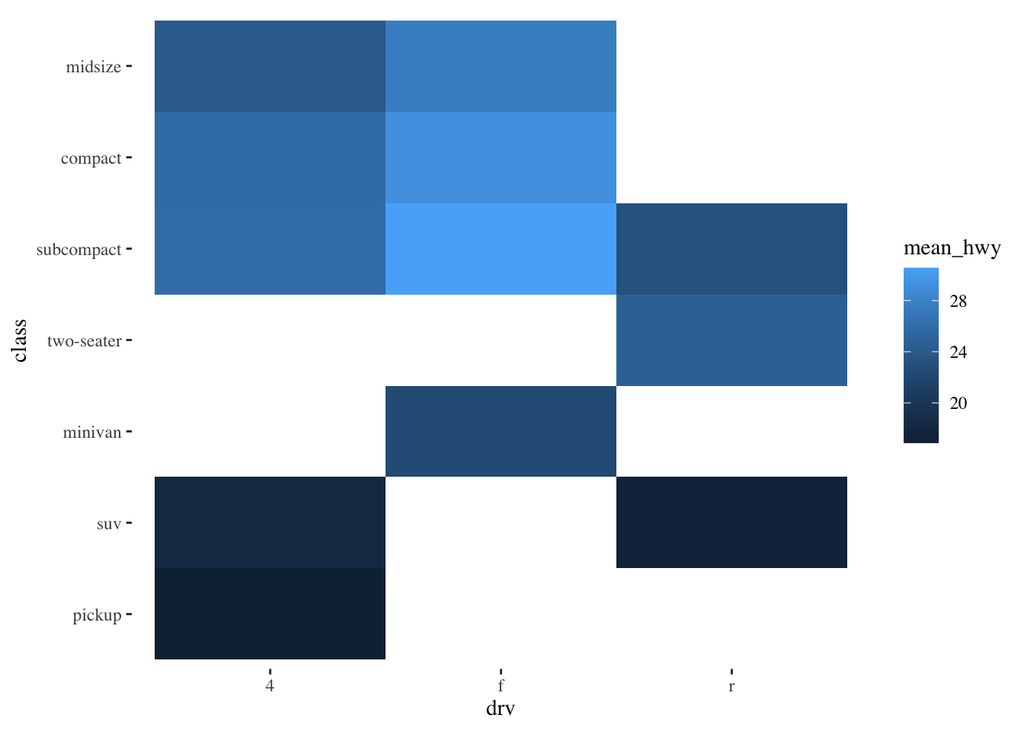

```r
mpg |>
  group_by(class, drv) |>
  summarize(mean_hwy=mean(hwy)) |>
  ggplot(aes(x=drv, y=class, fill=mean_hwy)) +
  geom_tile() +
  theme_tufte()
```

Heatmaps are `ggplot` figures, so we can customize them using the same tools we have already learned. We can change axis and legend labels with `labs()`, choose a theme, and control the fill colors using a `scale_fill_*()` function.

## Explore the Youth Risk Behavior Survey

### 1. Understand the dataset

Look through the YRBS documentation and briefly describe what the dataset contains and what one row represents.

```r
data <- read_csv("./courses/STAT118/data/yrbss_2024.csv")
```

### 2. Choose a variable

Find one variable that interests you. What does it measure, and what are its possible values?

### 3. Summarize it

Use `count()` or `group_by()` + `summarize()` to explore your variable.

### 4. Make a figure

Choose a second variable and create a visualization that helps you explore how the two variables are related.

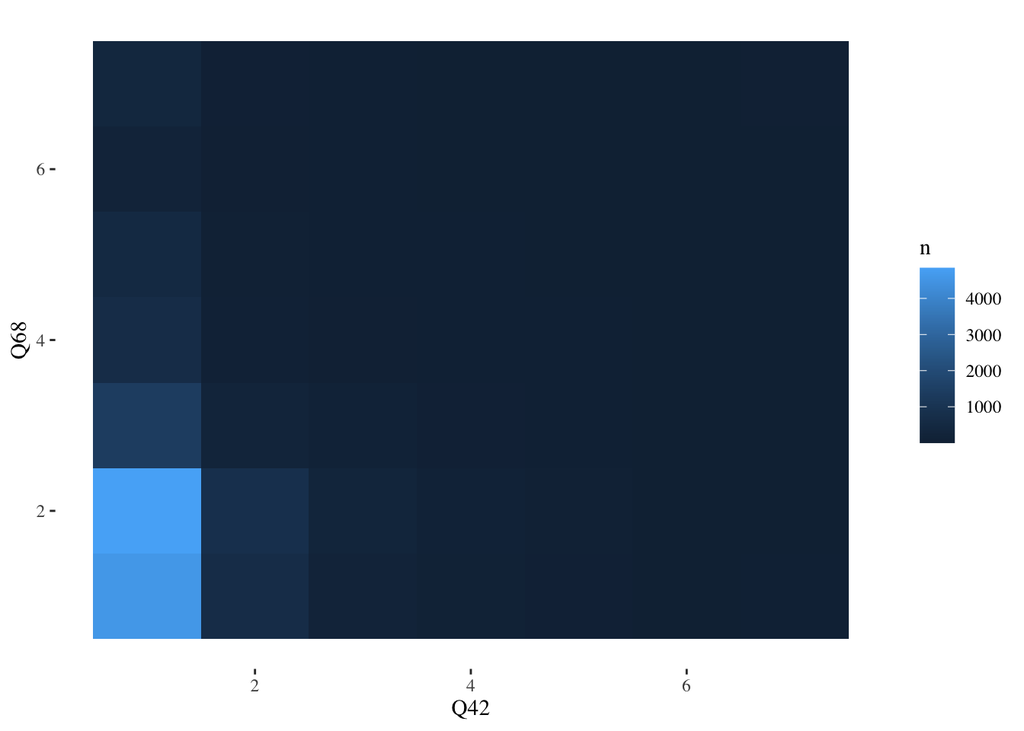

```r
# Q68 v Q42
# Q68 has to do with juice consumption and Q42 with alcohol consumption

data |>
  count(Q68, Q42) |>
  ggplot(aes(x=Q42, y=Q68, fill=n)) +
  geom_tile() +
  theme_tufte()
```

### 5. Ask a question

Based on what you found, write one question about the YRBS data that you would be interested in investigating further.